# Part I - (Dataset Exploration Title)

### change data type

```python
#retype the some of columns
bike_rides["user_type"]=bike_rides["user_type"].astype('category');
bike_rides["member_gender"]=bike_rides["member_gender"].astype('category');
bike_rides["bike_share_for_all_trip"]=bike_rides["bike_share_for_all_trip"].astype('category');
bike_rides["member_birth_year"]=bike_rides["member_birth_year"].astype('int64');
```

```python
#check the type of columns
bike_rides.info()
```

```
<class 'pandas.core.frame.DataFrame'>
RangeIndex: 174952 entries, 0 to 174951
Data columns (total 16 columns):
duration_sec               174952 non-null int64
start_time                 174952 non-null object
end_time                   174952 non-null object
start_station_id           174952 non-null float64
start_station_name         174952 non-null object
start_station_latitude     174952 non-null float64
start_station_longitude    174952 non-null float64
end_station_id             174952 non-null float64
end_station_name           174952 non-null object
end_station_latitude       174952 non-null float64
end_station_longitude      174952 non-null float64
bike_id                    174952 non-null int64
user_type                  174952 non-null category
member_birth_year          174952 non-null int64
member_gender              174952 non-null category
bike_share_for_all_trip    174952 non-null category
dtypes: category(3), float64(6), int64(3), object(4)
memory usage: 17.9+ MB
```

```python
bike_rides.describe()
```

|  | duration_sec | start_station_id | start_station_latitude | start_station_longitude | end_station_id | end_station_latitude | end_station_longitude | bike_id | member_birth_year |
| --- | --- | --- | --- | --- | --- | --- | --- | --- | --- |
| count | 174952.000000 | 174952.000000 | 174952.000000 | 174952.000000 | 174952.000000 | 174952.000000 | 174952.000000 | 174952.000000 | 174952.000000 |
| mean | 704.002744 | 139.002126 | 37.771220 | -122.351760 | 136.604486 | 37.771414 | -122.351335 | 4482.587555 | 1984.803135 |
| std | 1642.204905 | 111.648819 | 0.100391 | 0.117732 | 111.335635 | 0.100295 | 0.117294 | 1659.195937 | 10.118731 |
| min | 61.000000 | 3.000000 | 37.317298 | -122.453704 | 3.000000 | 37.317298 | -122.453704 | 11.000000 | 1878.000000 |
| 25% | 323.000000 | 47.000000 | 37.770407 | -122.411901 | 44.000000 | 37.770407 | -122.411647 | 3799.000000 | 1980.000000 |
| 50% | 510.000000 | 104.000000 | 37.780760 | -122.398279 | 101.000000 | 37.781010 | -122.397437 | 4960.000000 | 1987.000000 |
| 75% | 789.000000 | 239.000000 | 37.797320 | -122.283093 | 238.000000 | 37.797673 | -122.286533 | 5505.000000 | 1992.000000 |
| max | 84548.000000 | 398.000000 | 37.880222 | -121.874119 | 398.000000 | 37.880222 | -121.874119 | 6645.000000 | 2001.000000 |

I think the member who wrote birth year has sinned

```python
#change the year
bike_rides.loc[bike_rides['member_birth_year']==1878,'member_birth_year']=1978
```

```python
#show the shape
bike_rides.shape
```

```
(174952, 16)
```

### What is the structure of your dataset?

> This data set has 174952 rows × 16 columns

### What is/are the main feature(s) of interest in your dataset?

> I'm more interested to look at the data of the members characteristics and how this affects the duration of the trip.

### What features in the dataset do you think will help support your investigation into your feature(s) of interest?

> The features are duration_sec, user type, gender, birth year and bike_share_for_all_trip is the related features

## Univariate Exploration

> In this section, investigate distributions of individual variables. If you see unusual points or outliers, take a deeper look to clean things up and prepare yourself to look at relationships between variables.

> **Rubric Tip**: The project (Parts I alone) should have at least 15 visualizations distributed over univariate, bivariate, and multivariate plots to explore many relationships in the data set. Use reasoning to justify the flow of the exploration.

> **Rubric Tip**: Use the "Question-Visualization-Observations" framework throughout the exploration. This framework involves **asking a question from the data, creating a visualization to find answers, and then recording observations after each visualisation.**

> **Rubric Tip**: Visualizations should depict the data appropriately so that the plots are easily interpretable. You should choose an appropriate plot type, data encodings, and formatting as needed. The formatting may include setting/adding the title, labels, legend, and comments. Also, do not overplot or incorrectly plot ordinal data.

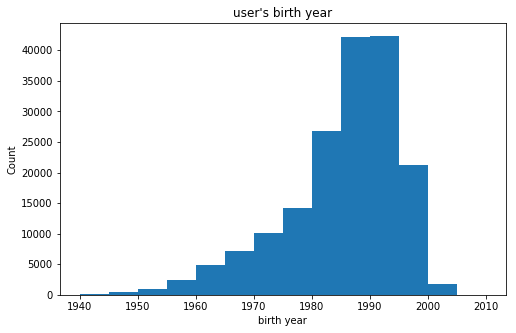

```python
# create member_birth_year bins
# plot histogram of member_birth_year
binsize = 10
bins = np.arange(1940, bike_rides['member_birth_year'].max()+binsize, 5)
plt.figure(figsize=[8, 5])
plt.hist(data = bike_rides, x = 'member_birth_year', bins = bins)
plt.xlabel('birth year')
plt.ylabel('Count');
plt.title('user\'s birth year')
plt.show()
```

This histogram is highly left-skewed which means the most of members are young.

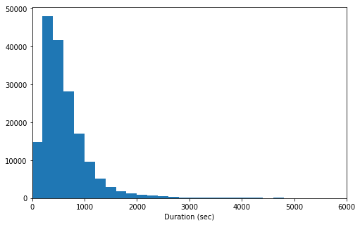

```python
# plot histogram of duration_sec
duration_bins = np.arange(0, bike_rides['duration_sec'].max(), 200)
plt.figure(figsize=[8, 5])
plt.hist(data=bike_rides, x='duration_sec', bins=duration_bins)
plt.xlim(0,6000)

plt.xlabel('Duration (sec)');
```

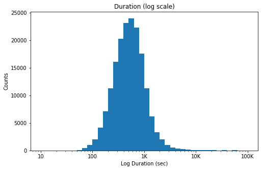

```python
#because there's a long tail in the distribution,so put it on a log scale instead
log_binsize = 0.1
bins = 10 ** np.arange(1, np.log10(bike_rides['duration_sec'].max())+log_binsize, log_binsize)
plt.figure(figsize=[8, 5])
plt.hist(data = bike_rides, x = 'duration_sec', bins = bins)
plt.xscale('log')
plt.xticks([10,100, 1000, 10000, 100000],[10,100,'1K','10K','100K'])
plt.title( 'Duration (log scale)')
plt.xlabel('Log Duration (sec)')
plt.ylabel('Counts');
plt.show()
```

Duration seconds has a long-tailed distribution, with a lot of members finishing the race in record time and some of them needing a long time to finish the race, when we plotted on a log scale, the Duration looked like an as normal distribution

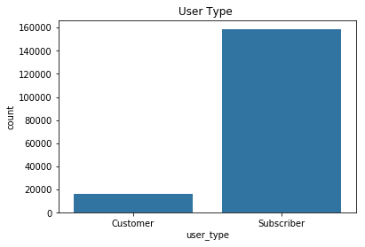

```python
# countplot of user_type
base_color =  sb.color_palette()[0]

sb.countplot(data=bike_rides, x='user_type', color=base_color);
plt.title('User Type ');
```

we have more then 150000 subscriber and almost 20000 customer in the race

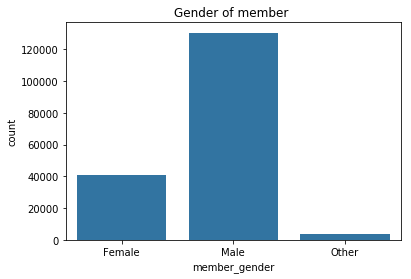

```python
# countplot of member_gender
sb.countplot(data=bike_rides, x='member_gender', color=base_color);
plt.title('Gender of member ');
```

most of members are male there's more then 120000 and we have 40000 Female

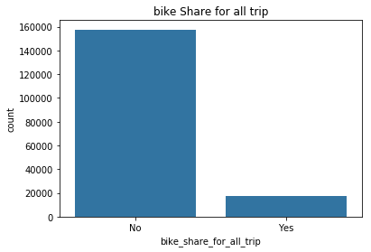

```python
#countplot of bike_share_for_all_trip
sb.countplot(data=bike_rides, x='bike_share_for_all_trip', color=base_color)
plt.title('bike Share for all trip');
```

when we look at the diagram we can see most of the members aren't shared in all trips. we have more than 150000 members who say (No) and we have almost 20000 who say (yes)

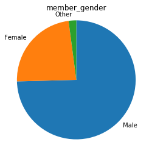

```python
# pieplot of member_gender
member_gender_counts = bike_rides['member_gender'].value_counts()
plt.pie(member_gender_counts, labels = member_gender_counts.index, startangle = 90, counterclock = False);
plt.axis('square');
plt.title('member_gender');
```

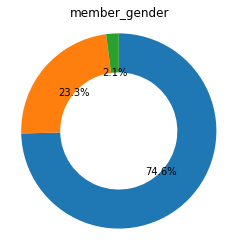

```python
# dountplot of member_gender
plt.pie(member_gender_counts, startangle = 90, autopct='%1.1f%%', counterclock = False,wedgeprops = {'width' : 0.4});
plt.axis('square');
plt.title('member_gender');
```

Almost men make up three quarters of the members with a percentage of about (74.6%) while women make up about (23.3%) while the rest are about (2.1%)

### Of the features you investigated, were there any unusual distributions? Did you perform any operations on the data to tidy, adjust, or change the form of the data? If so, why did you do this?

when investigating the member birth year we can see one member born in 1878 this looks mistake for that I changed it to 1978

## Bivariate Exploration

> In this section, investigate relationships between pairs of variables in your data. Make sure the variables that you cover here have been introduced in some fashion in the previous section (univariate exploration).

```python
numeric_vars = ['duration_sec', 'member_birth_year']
categoric_vars = ['user_type', 'member_gender', 'bike_share_for_all_trip']
```

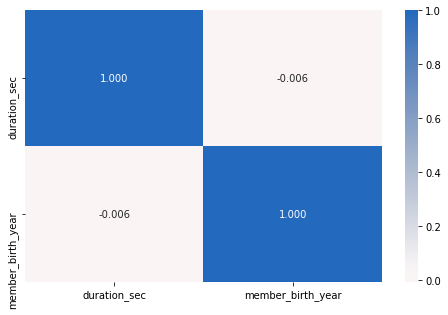

```python
# correlation heatmap plot between numeric variables
plt.figure(figsize = [8, 5])
sb.heatmap(bike_rides[numeric_vars].corr(), annot = True, fmt = '.3f',
            cmap = 'vlag_r', center = 0)
plt.show()
```

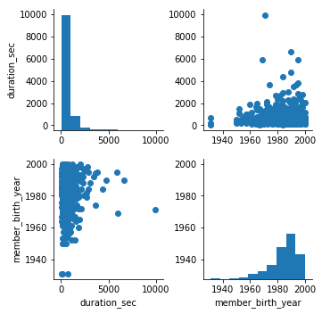

```python
# correlation scatter plot between numeric variables
bike_samples = bike_rides.sample(n=1000, replace = False)

PairGrid = sb.PairGrid(data=bike_samples, vars=numeric_vars)
PairGrid = PairGrid.map_diag(plt.hist)
PairGrid.map_offdiag(plt.scatter);
```

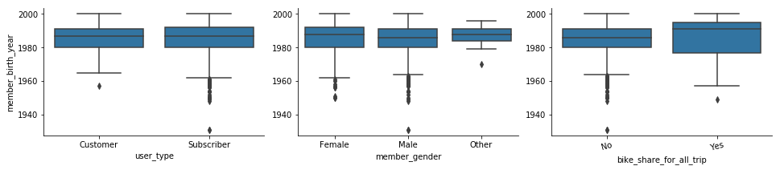

```python
bike_samples = bike_rides.sample(n=1000, replace = False)

def boxgrid(x, y, **kwargs):
    default_color = sb.color_palette()[0]
    sb.boxplot(x=x, y=y, color=default_color);

plt.figure(figsize = [10, 10])
g = sb.PairGrid(data = bike_samples, y_vars = 'member_birth_year', x_vars = categoric_vars,
                size = 3, aspect = 1.5);
g.map(boxgrid);
plt.xticks(rotation=15);

plt.show();
```

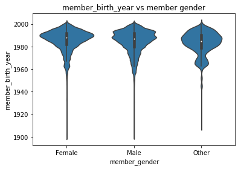

```python
# plot the categorical variables of member_birth_year vs member gender
sb.violinplot(data=bike_rides, x='member_gender', y='member_birth_year', color=base_color)
plt.title('member_birth_year vs member gender');
```

most of female born in 1990 and the most of also born in 1987 and 1995.

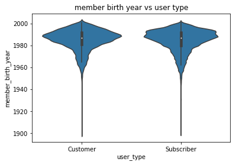

```python
# plot the categorical variables of member_birth_year vs user_type
sb.violinplot(data=bike_rides, x='user_type', y='member_birth_year', color=base_color)
plt.title('member birth year vs user type');
```

most of Subscriber born btween 1980 and 1995 and the same thing for Customer

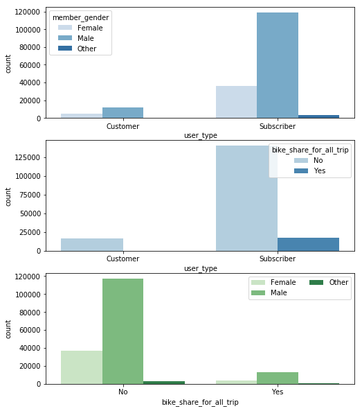

```python
plt.figure(figsize = [8, 10])

# subplot 1: user_type vs member_gender
plt.subplot(3, 1, 1)
sb.countplot(data=bike_rides, x='user_type', hue='member_gender', palette='Blues')

# subplot 2: user_type vs bike_share_for_all_trip
ax = plt.subplot(3, 1, 2)
sb.countplot(data=bike_rides, x='user_type', hue='bike_share_for_all_trip', palette='Blues')

# subplot 3: bike_share_for_all_trip vs member_gender
ax = plt.subplot(3, 1, 3)
sb.countplot(data=bike_rides, x='bike_share_for_all_trip', hue='member_gender', palette='Greens')
ax.legend(ncol=2);
```

```python
#remove outliers
bike_outliers = bike_rides[bike_rides['duration_sec']<3000]
bike_outliers.reset_index(drop=True, inplace=True)
```

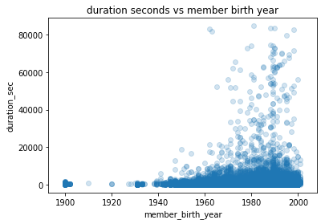

```python
# scatter plot duration_sec vs member_gender
sb.regplot(data=bike_rides, x='member_birth_year', y='duration_sec',
            fit_reg=False, scatter_kws={'alpha': 0.2});
plt.title('duration seconds vs member birth year');
```

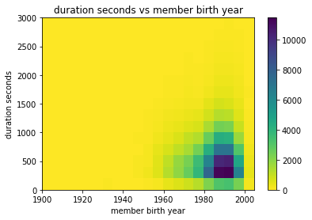

```python
# hist2d  plot duration_sec vs member_gender
birth_bins_x = np.arange(1900, bike_outliers.member_birth_year.max()+5, 5)
birth_bins_y = np.arange(0, bike_outliers.duration_sec.max()+200, 200)
plt.hist2d(data=bike_outliers, x='member_birth_year', y='duration_sec', bins=[birth_bins_x, birth_bins_y],
           cmap = 'viridis_r')
plt.colorbar()
plt.title('duration seconds vs member birth year');
plt.xlabel('member birth year')
plt.ylabel('duration seconds');
```

here we can see extreme, many members who ride bikes for about 500 seconds, they born between 1980 and 2000.

### Talk about some of the relationships you observed in this part of the investigation. How did the feature(s) of interest vary with other features in the dataset?

as we expected most of the members were fished the trip in 500 seconds and they are born between 1980 and 2000. also, we can see the scatter there were some members were needing more than 2000 seconds to fished the trip but The strange thing they born between 1970 and 2000 observed. the third thing is the subscriber and Customers most of them are born between 1980 and 2000 too. the fourth thing is that most subscribers and Customers are male more than female.

### Did you observe any interesting relationships between the other features (not the main feature(s) of interest)?

No

## Multivariate Exploration

> Create plots of three or more variables to investigate your data even further. Make sure that your investigations are justified, and follow from your work in the previous sections.

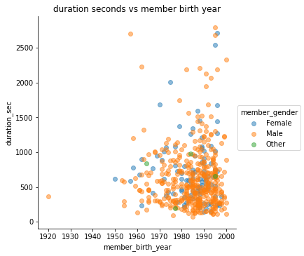

```python
bike_samples = bike_outliers.sample(n=500, replace = False)
g = sb.FacetGrid(data=bike_samples,hue='member_gender' ,size=5)
g.map_dataframe(plt.scatter,"member_birth_year",'duration_sec',alpha = 0.5)
g.add_legend();
plt.title('duration seconds vs member birth year');
```

here I use a sample from 500 members that find the relation between duration of trip and birth year and filtered by gender, and we can see the no big difference between male and females in duration of the trip.

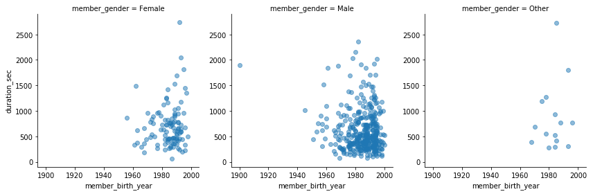

```python
bike_samples = bike_outliers.sample(n=500, replace = False)

g = sb.FacetGrid(data = bike_samples, col = 'member_gender', size = 4,
                margin_titles = True)
g.map(plt.scatter, 'member_birth_year', 'duration_sec',alpha = 0.5)
```

we have three diagrams for every gender.

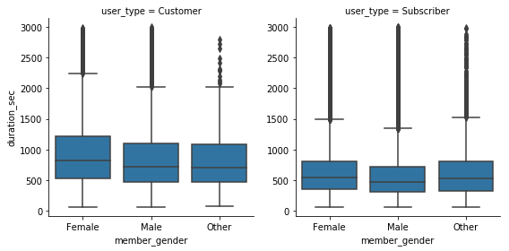

```python
g = sb.FacetGrid(data = bike_outliers, col = 'user_type', size =4)
g.map(sb.boxplot, 'member_gender', 'duration_sec');
```

```python
hour_bins_x = np.arange(0, bike_outliers.member_birth_year.max()+1, 1)
```

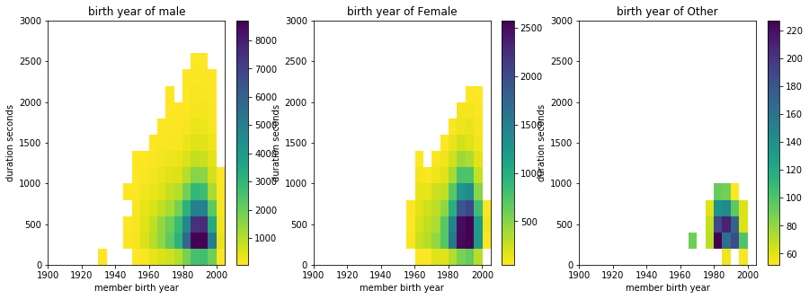

```python
bike_outliers_male = bike_outliers[bike_outliers['member_gender']=='Male']
bike_outliers_female = bike_outliers[bike_outliers['member_gender']=='Female']
bike_outliers_other = bike_outliers[bike_outliers['member_gender']=='Other']

plt.figure(figsize = [15,5])

plt.subplot(1,3, 1)
plt.hist2d(data=bike_outliers_male, x='member_birth_year', y='duration_sec', bins=[birth_bins_x, birth_bins_y],
           cmap = 'viridis_r', cmin=50)
plt.colorbar()
plt.title('birth year of male');
plt.xlabel('member birth year')
plt.ylabel('duration seconds');


plt.subplot(1, 3, 2)
plt.hist2d(data=bike_outliers_female, x='member_birth_year', y='duration_sec', bins=[birth_bins_x, birth_bins_y],
           cmap = 'viridis_r', cmin=50);
plt.colorbar()
plt.title('birth year of Female');
plt.xlabel('member birth year')
plt.ylabel('duration seconds');


plt.subplot(1, 3, 3)
plt.hist2d(data=bike_outliers_other, x='member_birth_year', y='duration_sec', bins=[birth_bins_x, birth_bins_y],
           cmap = 'viridis_r', cmin=50);
plt.colorbar()
plt.title('birth year of Other');
plt.xlabel('member birth year')
plt.ylabel('duration seconds');
```

some male members need more than 2000 seconds to finish the trip.

[figure not shown]

```python
cat_count = bike_outliers.groupby(['user_type', 'member_gender']).count()['duration_sec']
cat_count = cat_count.reset_index(name = 'duration_sec')
cat_count = cat_count.pivot(index = 'member_gender', columns = 'user_type',
                            values = 'duration_sec')
sb.heatmap(cat_count, annot = True, fmt = '.3f',
           cbar_kws = {'label' : 'mean(duration_sec)'},cmap='viridis_r')
plt.title('member gender  vs user type');
```

the most Subscriber is male

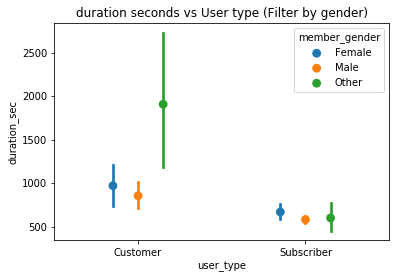

```python
ax = sb.pointplot(data = bike_samples, x = 'user_type', y = 'duration_sec', hue = 'member_gender',
                  dodge = 0.3, linestyles = "")
plt.title('duration seconds vs User type (Filter by gender)');
```

in here we take the smple and show User type and duration trip filter filted by gender.

### Talk about some of the relationships you observed in this part of the investigation. Were there features that strengthened each other in terms of looking at your feature(s) of interest?

The main ideas are quite the same as bivariate plots with more information. First, we have the Scatter plot and we get the same result in the bivariate plots except we make the simple then we see the relationship between the duration of seconds and relationship member birth year. we get the Female member younger than the male. the male Subscriber is 118314 and this is higher than Male customer also from female Subscriber and female custome but the female Subscriber is higher the male Customer.